# Data Breaches Research

Sharon Velasquez

2023-02-22

# Data Breaches Research

This research is intended to help organizations understand how to prepare for & avoid data breaches in the future. For this research uses recorded data breaches in private & public organizations since 2004 to 2022. You can find the original data in the Wikipedia entry [“List of data breaches”](https://en.wikipedia.org/wiki/List_of_data_breaches).

## Objectives

1. Identify which industries are more vulnerable to cyber attacks.
2. Determine if the number data breaches have increased over the years.
3. Uncover which methods of attacks are the most common.

## The Data

To begin this research I copied the data directly from the table into a csv file. The I reviewed the data to see what needed to be cleaned and identify any missing information.

### Data Cleaning

Within the csv file I reviewed the information and performed the following tasks:

## The Research

To begin this research in **R Studio** I started by installing the packages I would need. In this case I will be using the *Tidyverse* and *Gggplot2* packages.

```r
install.packages("tidyverse")
```

```r
install.packages("ggplot2")
```

Then run the libraries necessary for this project.

```r
library(readr) #to read the csv file
library(dplyr) #to see summaries of the data & manipulate it
library(tidyr) #to clean the data
```

Now it’s time to import the csv file and store it in the variable *dataBreaches*:

```r
dataBreaches <- read_csv("DataBreaches.csv")
```

To double check that the data was imported properly I decided to get a quick preview of the table:

```r
glimpse(dataBreaches) #to see all columns and a few top records
```

```
## Rows: 353
## Columns: 5
## $ Entity           <chr> "2018 British Airways cyberattack", "2019 Bulgarian r…
## $ Year             <dbl> 2018, 2019, 2016, 2022, 2020, 2020, 2019, 2013, 2017,…
## $ Records          <chr> "500000", "over 5,000,000", "2200000", "6400000", "14…
## $ OrganizationType <chr> "transport", "government", "healthcare", "various", "…
## $ Method           <chr> "hacked", "hacked", "hacked", "poor security", "hacke…
```

```r
head(dataBreaches) #to see the top records
```

```
## # A tibble: 6 × 5
##   Entity                                    Year Records        Organiz…¹ Method
##   <chr>                                    <dbl> <chr>          <chr>     <chr>
## 1 2018 British Airways cyberattack          2018 500000         transport hacked
## 2 2019 Bulgarian revenue agency hack        2019 over 5,000,000 governme… hacked
## 3 21st Century Oncology                     2016 2200000        healthca… hacked
## 4 50 companies and government institutions  2022 6400000        various   poor …
## 5 500px                                     2020 14870304       social n… hacked
## 6 Accendo Insurance Co.                     2020 175350         healthca… poor …
## # … with abbreviated variable name ¹OrganizationType
```

### Data breaches by methodology

Now I will group & count occurrences of data breaches by the method used to uncover which measures organizations should take to protect their data.

For this I will first create a new data frame that I will store in the variables *breachMethod*:

```r
breachMethod <- dataBreaches %>% group_by(Method) %>%  drop_na() %>% count(Method)

#Rename the breachMethod n column to totalBreaches
colnames(breachMethod)[2] <- "totalBreaches"

#organize the results in descending order to see the most used method in data breaches
View(breachMethod %>% arrange(-totalBreaches))
```

```
## Error in .External2(C_dataviewer, x, title): unable to start data viewer
```

Now that we have an idea of the information in the table is a good time to create a graph to have a better idea of what that information looks like.

Run the *ggplot2* library first:

```r
library(ggplot2)
```

Now it’s time to create a chart. To represent this data I decided to use a column chart, because it would make it easier to compare each category.

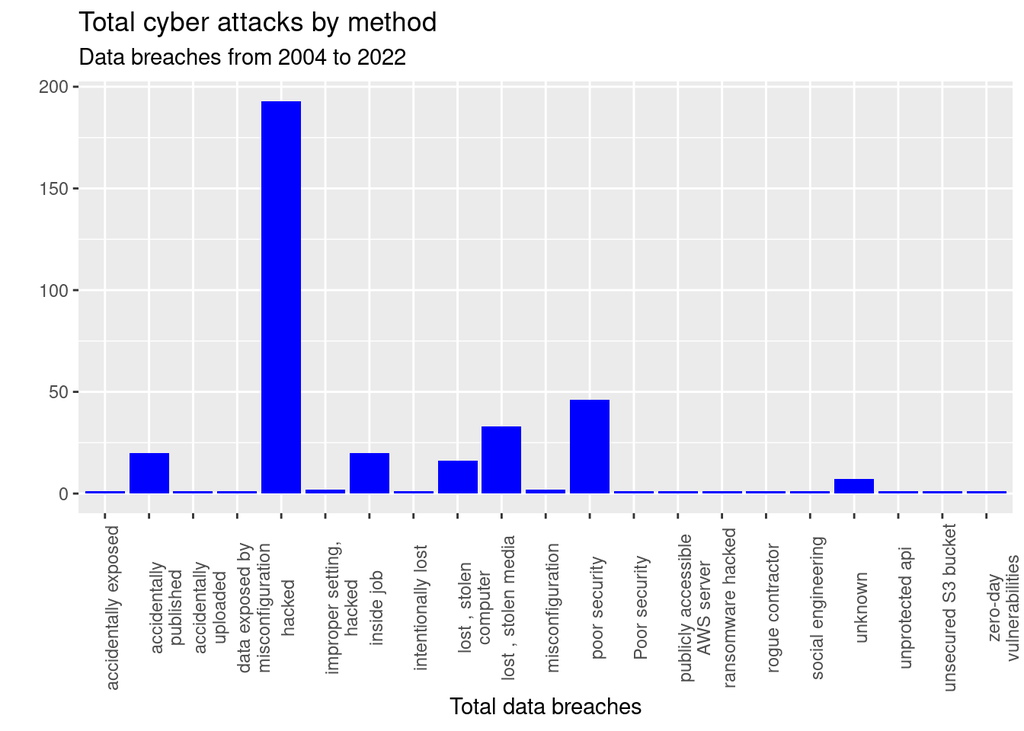

```r
ggplot(breachMethod,aes(x=Method,y=totalBreaches))+geom_col(fill="blue") +
  theme(axis.text.x = element_text(angle=90))+scale_x_discrete(labels = function(x) stringr::str_wrap(x,width=20)) +
  labs(title="Total cyber attacks by method", subtitle="Data breaches from 2004 to 2022", x="Total data breaches", y=" ")
```

Next, we will review data breaches by industry.

### Data breaches by Industry

Now I will group and count occurrences of data breaches by industry to determine which industries are more likely to suffer a cyber security attack.

To start I will compute the total number of data breaches that occurred by industry, and I will store it in a new variable called *industryBreaches*. Then I will rename the second column to a more descriptive name called *totalBreaches* that will contain the total occurrences.

```r
industryBreaches <- dataBreaches %>% group_by(OrganizationType)  %>% count(OrganizationType)

#rename the 2nd column
colnames(industryBreaches)[2] <- "totalBreaches"

 #now organize a view with the higher total number of breaches first
View(industryBreaches %>% arrange(-totalBreaches))
```

```
## Error in .External2(C_dataviewer, x, title): unable to start data viewer
```

This gives us over 70 lines of data. We can now build a graph to see the result. For this I decided to use a lollipop graph vertically stacked.

Because there are so many results it the graph would be difficult to read with so many lines of data. Thus, we will filter the data that will in this graph to only show industries with more than one hack.

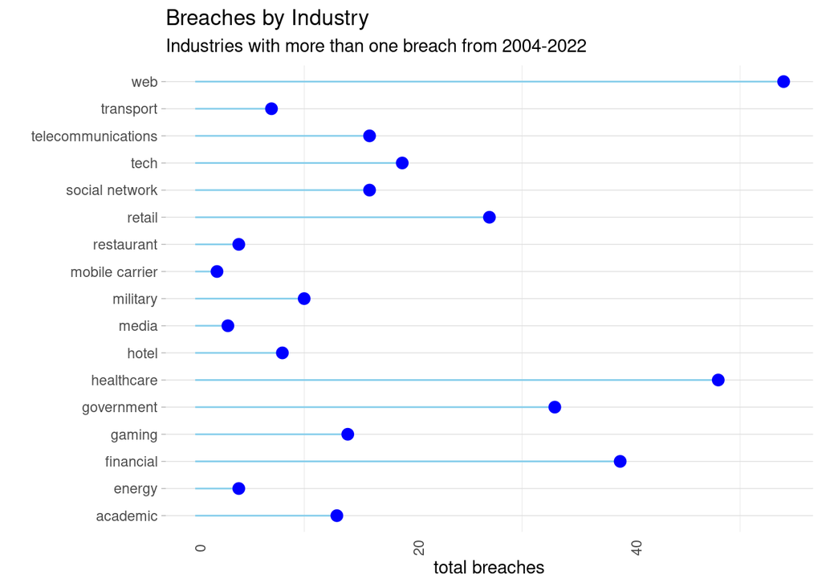

```r
ggplot(industryBreaches[which(industryBreaches$totalBreaches>1),], aes(x=OrganizationType,y=totalBreaches)) +
  geom_segment(aes(x=OrganizationType,xend=OrganizationType, y=0, yend=totalBreaches), color="skyblue")+
  geom_point(color="blue",size=3)+ theme_light() + coord_flip() +
  theme(panel.grid.major.x = element_blank(), panel.border = element_blank(),axis.ticks.x = element_blank(), axis.text.x=element_text(angle=90))+
  labs(title="Breaches by Industry",subtitle="Industries with more than one breach from 2004-2022",x=" ",y="total breaches")
```

Finally, we will determine if the total data breaches have increased or decreased over the years.

### Data breaches by year

Fist I will create a new data frame where I will compute the number of occurrences per year. Then I will organize the data by year.

```r
yearlyBreaches<- dataBreaches %>% group_by(Year) %>%  drop_na() %>% count(Year)

#rename the 2nd column
colnames(yearlyBreaches)[2] <- "totalBreaches"

View(yearlyBreaches %>% arrange(-totalBreaches))
```

```
## Error in .External2(C_dataviewer, x, title): unable to start data viewer
```

Now I will create a bar chart to see the results.

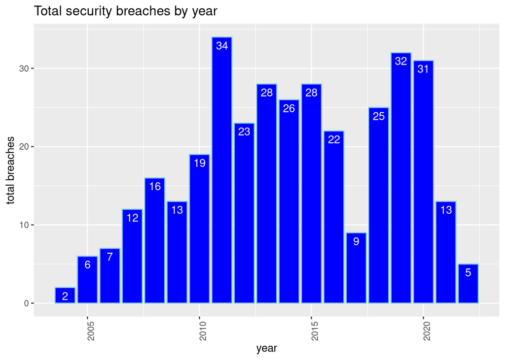

```r
ggplot(yearlyBreaches[which(yearlyBreaches$totalBreaches>1),], aes(x=Year, y=totalBreaches)) +
  geom_bar(color="skyblue",fill="blue",stat="identity") + theme(axis.text.x = element_text(angle = 90)) +
  geom_text(aes(label = totalBreaches), vjust = 1.5, color="white") +
  labs(title="Total security breaches by year",x="year",y="total breaches")
```

Based on the results more the amount of data breaches peaked on 2011, but have decreased in recent years. This could be a result of improvements in security and organizations investing more in cyber security measures.

## Conclusions

Based on the results I would suggest organizations in to invest in increasing security measures to protect their servers. As seen the leading method for hackers is through direct hack attacks. However, it is important that companies also do routine checks to find weak points in their current security measures. This includes adding cyber security training for their employees and stricter data governance measures.

These suggestions are specially important for governments & organizations within the financial, retail, & healthcare industries.

Companies with online products & services seem to be specially vulnerable, thus it is adviced that they heavily invest resources into protecting their clients & their internal information.